# HW9: Car Theft Confidence Intervals & Margin of Error

Your editor wants to know what a “typical” month of car thefts looks like in Prince George’s County. Not just the average — she wants to know how confident you can be in that number. Using monthly figures, confidence intervals and margin of error, you’ll come up with an answer and decide whether the data supports a clear story. As with the previous homework, provide answers in this notebook when prompted and you will have to fill in values where you see REPLACE_ME. Get started by loading the tidyverse in a new R block.

### Task 1: Load the tidyverse

### Task 2: Load the Prince George’s county crime data

```r
# Read the data
car_thefts <- read_csv("https://raw.githubusercontent.com/dwillis/jour405/refs/heads/main/data/car_thefts_month.csv") |>
  arrange(month)  # Sort by date
# Basic inspection of the data
glimpse(car_thefts)
```

```
## Rows: 32
## Columns: 2
## $ month <date> 2023-07-01, 2023-08-01, 2023-09-01, 2023-10-01, 2023-11-01, 202…
## $ total <dbl> 611, 544, 427, 481, 478, 498, 393, 412, 335, 279, 394, 442, 421,…
```

### Task 3: Let’s make a chart and describe the results.

We’ll make a line chart using geom_line() to try and illustrate any trend over time. What’s your initial reaction to the change in car thefts? Is there a trend? If your editor asked you “how many car thefts happen in a typical month?”, what would you say based on this chart alone?

On average the trend is that car thefts have gone down. When you break it down annually they tend to fluctuate higher in the middle to end of the year, but on a whole even, with this pattern there is a clear decrease.

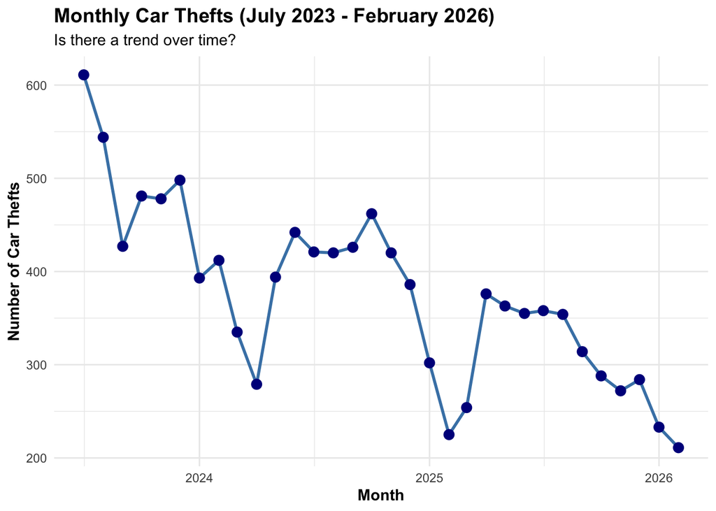

```r
car_thefts |>
ggplot(aes(x = month, y = total)) +
  geom_line(color = "steelblue", size = 1) +
  geom_point(color = "darkblue", size = 3) +
  labs(
    title = "Monthly Car Thefts (July 2023 - February 2026)",
    subtitle = "Is there a trend over time?",
    x = "Month",
    y = "Number of Car Thefts"
  ) +
  theme_minimal() +
  theme(
    plot.title = element_text(face = "bold", size = 14),
    axis.title = element_text(face = "bold")
  )
```

### Task 4: Calculate the mean, standard error and margin of error

We’ve got a small number of months, so we need to quantify the uncertainty around our average. We’ll calculate the standard error (which measures how much the sample mean could vary), and the margin of error (which gives us the plus/minus range). Replace the REPLACE_ME values based on what we did in class.

```r
theft_summary <- car_thefts |>
  summarize(
    mean_thefts = mean(total),
    sd_thefts = sd(total),
    months = n(),
    se_thefts = sd_thefts / sqrt(months),
    margin_error = qt(0.975, df = months - 1) * se_thefts
  )

# Display the results
theft_summary
```

```
## # A tibble: 1 × 5
##   mean_thefts sd_thefts months se_thefts margin_error
##         <dbl>     <dbl>  <int>     <dbl>        <dbl>
## 1        376.      94.8     32      16.8         34.2
```

**Answer this question:** Explain in your own words what the margin of error tells us here. If you were writing a story, how would you use this number? For example, how would you complete this sentence: “Prince George’s County averages about ___ car thefts per month, plus or minus ___.”

Prince George’s County averages about 376 car thefts per month, plus or minus 34.

### Task 5: Build the confidence interval

Now let’s turn the margin of error into a full confidence interval — the range where we’re 95% confident the true average falls. Replace the REPLACE_ME values.

```r
theft_summary <- theft_summary |>
  mutate(
    ci_lower = mean_thefts - margin_error,
    ci_upper = mean_thefts + margin_error
  )

theft_summary |>
  select(mean_thefts, margin_error, ci_lower, ci_upper)
```

```
## # A tibble: 1 × 4
##   mean_thefts margin_error ci_lower ci_upper
##         <dbl>        <dbl>    <dbl>    <dbl>
## 1        376.         34.2     341.     410.
```

**Answer this question:** If a county official claimed “car thefts are down to about 300 per month,” does your confidence interval support that claim? What about a claim of 350 per month? Explain how the confidence interval helps you evaluate each claim.

The 95% confidence interval ranges from 341-410 car thefts per month. The claim that they’re down to 300 per month is not supported by the data because 300 is below the lower bound of the confidence interval- outside range we consider plausible. The claim of 350 would be supported because it falls inside the range. Confidence interval helps us because: inside range= plausible, outside range= not plausible although may be very rare exceptions.

### Task 6: Visualize the data with the confidence interval

Let’s make a chart showing the data with the mean and the 95% confidence interval. Does this change anything about your answer from Task 3?

No because the mean comapred to the starting amount of thefts and the end amount of thefts shows that it is right in th middle of two very opposite totals, meanding there is an obvious decline in thefts. In fact, there is only one point that falls on the average line and it is from an abnormal fluctuation from the beginning of 2025. From that point onwards, car thefts decrease.

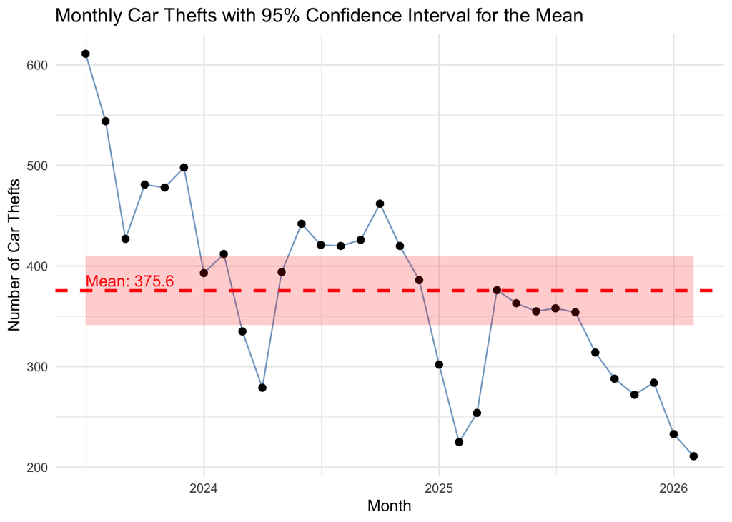

```r
# Make a chart with the mean and CI
car_thefts |>
ggplot(aes(x = month, y = total)) +
  geom_line(color = "steelblue", alpha = 0.7) +
  geom_point(size = 2) +
  geom_hline(yintercept = theft_summary$mean_thefts, linetype = "dashed", color = "red", size = 1) +
  geom_ribbon(aes(ymin = theft_summary$ci_lower, ymax = theft_summary$ci_upper),
              fill = "red", alpha = 0.2) +
  annotate("text", x = min(car_thefts$month),
           y = theft_summary$mean_thefts + 10,
           label = paste0("Mean: ", round(theft_summary$mean_thefts, 1)),
           hjust = 0, color = "red") +
  labs(
    title = "Monthly Car Thefts with 95% Confidence Interval for the Mean",
    x = "Month",
    y = "Number of Car Thefts"
  ) +
  theme_minimal()
```

### Task 7: The margin of error and sample size

In class we learned that MoE = 1/√n × 100 as a quick approximation for polls. That same principle applies here: more data means a smaller margin of error. Let’s see what would happen if we had 40 months of data instead of the number we have, assuming the same mean and standard deviation. Replace the REPLACE_ME value with 40.

```r
hypothetical_summary <- tibble(
  mean_thefts = theft_summary$mean_thefts,
  sd_thefts = theft_summary$sd_thefts,
  months = 40,
  se_thefts = sd_thefts / sqrt(months),
  margin_error = qt(0.975, df = months - 1) * se_thefts,
  ci_lower = mean_thefts - margin_error,
  ci_upper = mean_thefts + margin_error
)

# Compare the two
comparison <- tibble(
  scenario = c("Actual data", "40 months"),
  months = c(theft_summary$months, hypothetical_summary$months),
  margin_error = c(theft_summary$margin_error, hypothetical_summary$margin_error),
  ci_lower = c(theft_summary$ci_lower, hypothetical_summary$ci_lower),
  ci_upper = c(theft_summary$ci_upper, hypothetical_summary$ci_upper)
)

comparison
```

```
## # A tibble: 2 × 5
##   scenario    months margin_error ci_lower ci_upper
##   <chr>        <dbl>        <dbl>    <dbl>    <dbl>
## 1 Actual data     32         34.2     341.     410.
## 2 40 months       40         30.3     345.     406.
```

**Answer this question:** How did the margin of error and confidence interval change? What does this tell you about the tradeoff between having more data and being able to make precise claims? If you were covering crime trends, how many months of data would you want before writing a definitive story?

### Task 8: Reporting with uncertainty

Based on everything you’ve calculated, answer the following:

1. Write a headline and a one-paragraph lede about car thefts in Prince George’s County. Your text should properly reflect the uncertainty in the data — don’t overstate or understate what the numbers show.
2. Your editor says “Just tell me if car thefts are going up or down.” Using only the confidence interval (no significance testing yet), what’s the most accurate answer you can give? What would you need to do next to answer that question more definitively?
1. Car Thefts Average around 376 a Month in Prince George’s County

2. Looking at thw graphs I would say that theft are decreasing but using just the confidence interval the real answer i that we cannot determine whether they’re going up or down based on the CI alone. The CI only tells us about overall average. To answer more definitively, we would need to run trend analysis tests like a regression test or another stat test to see whether there is a significant increase or decrease over time.

When you are finished, save your work, switch to GitHub Desktop, then add, commit and push your changes to GitHub and submit the URL of the notebook in ELMS.